# 成為初級資料分析師 | Python 機器學習

> 分類

## 郭耀仁

## 大綱

- 未經過訓練的分類器（Dummy classifiers）
- 羅吉斯回歸分類器（Logistic Regression Classifier）
- 正規化
- 二元至多元（One vs. All）
- 不同的分類模型評估指標

## 未經過訓練的分類器（Dummy classifiers）

## 未經過訓練的分類器

> 使用簡單守則對資料進行分類，像是許多的 `if` 條件式

## 常見未經過訓練的分類器

- 硬幣
- 專家意見
- ...etc.

## 投擲硬幣來分類球員是否為前場

```python
import pandas as pd
import numpy as np
from sklearn.model_selection import train_test_split

csv_url = "https://pyml.s3-ap-northeast-1.amazonaws.com/nba/players.csv"
players = pd.read_csv(csv_url)
pos = players["pos"].values
y = np.array(list(map(lambda x: 0 if x[0] == 'G' else 1, pos)))
print(pos[:10])
print(y[:10])
y_train, y_validation = train_test_split(y, test_size=0.33, random_state=42)
```

```
['C' 'C-F' 'C-F' 'F-C' 'G' 'G' 'C' 'G' 'F' 'F-G']
[1 1 1 1 0 0 1 0 1 1]
```

```python
y_pred = np.random.randint(0, 2, size=y_validation.size)
y_pred = np.array(y_pred)
print(y_pred)
```

```
[0 1 1 0 0 1 1 0 1 0 0 1 0 1 0 0 0 0 1 1 0 0 1 0 1 0 1 0 1 0 0 0 1 1 0 1 1
 0 0 0 1 1 1 0 0 1 1 1 0 1 1 0 1 0 0 1 0 0 1 1 0 0 1 1 1 1 0 0 0 1 1 0 0 0
 0 0 1 0 1 0 1 0 0 0 1 1 1 0 1 0 0 0 1 0 1 1 1 1 1 1 1 1 0 1 1 0 1 1 0 1 0
 0 0 1 0 1 0 1 1 1 1 1 1 1 1 1 1 0 0 1 1 1 1 0 0 1 0 0 1 0 0 0 1 1 0 0 0 1
 0 0 1 0 0 1 1 0 0 1 0 0 1 0 1 1 1]
```

## 投擲硬幣分類球員是否為前場球員準不準？

[figure not shown]

Source: https://en.wikipedia.org/wiki/Confusion_matrix

```python
n_tp_tn = (y_pred == y_validation).sum()
n_validations = y_validation.size
print("Accuracy score: {:.2f}%".format(n_tp_tn*100/n_validations))
```

```
Accuracy score: 52.12%
```

## 聽聞專家意見預測來分類球員是否為前場

> 前場球員身高普遍比後場球員高

```python
print("Accuracy score: {:.2f}%".format(acc*100))
```

[output not shown]

```
Accuracy score: 89.09%
```

## 分類模型的 E, T, 與 P

> A computer program is said to learn from experience E with respect to some class of tasks T and performance measure P if its performance at tasks in T, as measured by P, improves with experience E.

> Tom Mitchel

## E: Experience

NBA 球員的身高

## T: Task

依據一名球員的身高預測他在球場上的位置

```python
import numpy as np

X_test = np.array([1.98]).reshape(-1, 1) # 一位身高 198 cm 的球員
X_test = np.array([1.83]).reshape(-1, 1) # 一位身高 183 cm 的球員
```

## P: Performance

- 跟 $f$ 長得很像的 $h$，分類與後來在球場上的位置相同
- 跟 $f$ 長得不太像的 $h$，分類與後來在球場上的位置不相同

## 羅吉斯回歸分類器（Logistic Regression Classifier）

## 分類器的輸出亦可以機率表示：給定 $x$ 其類別為 $C_i$ 的機率為何

$$ \sigma(x^Tw) = P(C_i | x) $$

## 分類模型 in short

建立一個輸入向量 $x$ 能夠得到純量 $\hat{y}$ 輸入的系統 $h$，其中向量 $w$ 稱為是系統的參數、$\hat{y}$ 則是一個離散值，經由某些函數（$g$）將 $h$ 轉換而得

$$ \hat{y} = g(h(x)) = g(w^Tx) \\ \hat{y} = g(h(X)) = g(Xw) \\ $$

## 使用誤分類數評估 $h$ 跟 $f$ 的相似程度

$$J(h)_{test} = \sum^{n_{test}}\delta (\hat{y} \neq y_{test})$$

## 如何從連續型的輸出 $Xw$ 到離散型的輸出 $\hat{y}$

$$ \hat{y} = g(h(X)) = H(\sigma(Xw)) $$

## 其中 $\sigma$ 俗稱為激勵函數（Activation function），$H$ 稱為階躍函數（Step function）

- 激勵函數將連續型輸出轉換為機率
- 階躍函數將機率輸出轉換為離散值

## 激勵函數將連續型輸出轉換為機率，羅吉斯回歸使用 sigmoid 函數

$$\sigma(Xw) = \frac{1}{1+e^{-Xw}}$$$$\sigma(z) = \frac{1}{1+e^{-z}}$$

## Sigmoid 函數的外觀

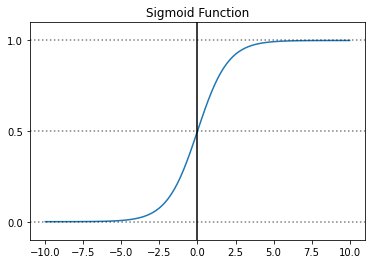

```python
z = np.linspace(-10, 10, 100)
get_sigmoid_plot(z)
```

## 將機率轉換為 $\hat{y} \in {\{0, 1\}}$

$$ \hat{y} = H(\sigma(z), prob) = \begin{cases} 1 & \quad \text{if } \sigma(z)\geq prob\\ 0 & \quad \text{otherwise}\\ \end{cases} $$

## 拆解羅吉斯回歸分類器的步驟

- 尋找 $h(X) = Xw$ 的 $w$
- 將 $h(X)$ 的輸出 $z$ 作為 Sigmoid 函數的輸入，得到 $\sigma(z)$
- 將 $\sigma(z)$ 作為 $H$ 的輸入，得到 $\hat{y}$

## 在迴歸問題中我們尋找 $h(X) = Xw$ 的 $w$ 是根據一個目標：讓成本函數 MSE 最小化

## 在分類問題中我們尋找 $h(X) = Xw$ 的 $w$ 則是依據：讓誤分類數最小化

$$J(h)_{test} = \sum^{n_{test}}\delta (\hat{y} \neq y_{test})$$

## 為了讓誤分類數最小化，得在尋找 $w$ 的過程中設計成本函數 $J$

$$ J(w) = \frac{1}{m}\big(-ylog\,(\sigma(Xw))-(1-y)log(1-\sigma(Xw))\big)\\ = \frac{1}{m}\big(-ylog(\sigma(z))-(1-y)log(1-\sigma(z))\big)\\ J(w) = \frac{1}{m}\big(-log(\sigma(z))\big) ,\text{ where y = 1} \\ J(w) = \frac{1}{m}\big(-log(1-\sigma(z))\big) ,\text{ where y = 0} $$

## 經過設計的成本函數 $J$ 稱為交叉熵（Cross-entropy）或 Log Loss

## 交叉熵（Cross-entropy）或 Log Loss 成本函數設計的巧妙處在於讓錯誤分類的成本趨近無限大

- 真實的 $y$ 為 1，$\sigma(z)$ 若離 0 比較近則成本將趨近無限大
- 真實的 $y$ 為 0，$\sigma(z)$ 若離 1 比較近則成本將趨近無限大

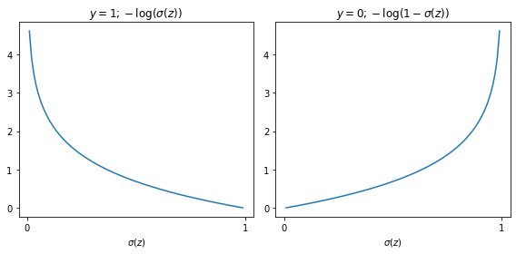

```python
x = np.arange(0.01, 1, 0.01)
get_cross_entropy_plot(x)
```

## 自訂 `get_cross_entropy()` 函數

```python
import numpy as np

def sigmoid(z):
    return(1 / (1 + np.exp(-z)))

def get_cross_entropy(X, y, w, epsilon=1e-8):
    m = y.size
    z = X.dot(w)
    h = sigmoid(z)
    y_reshaped = y.reshape(-1, 1).copy()
    cross_entropy = (-y_reshaped.T.dot(np.log(h)) - (1 - y_reshaped).T.dot(np.log(1 - h))) / m
    return cross_entropy[0, 0]
```

## 欲使用梯度遞減找到一組 $w$ 讓 $J(w)$ 最小化，得先計算梯度

$$ J(w) = -\frac{1}{m}\big(y\,log\,(\sigma(Xw))+(1-y)(\,log\,(1-\sigma(Xw))\big) \\ .\\ \text{...chain rules, the derivative of sigmoid function...} .\\ \frac{\mathrm \partial}{\mathrm \partial w} J(w) = \frac{1}{m}X^T\big(\sigma(Xw) - y\big) $$

Sources:

- http://math.stackexchange.com/questions/78575/derivative-of-sigmoid-function-sigma-x-frac11e-x
- https://stats.stackexchange.com/questions/278771/how-is-the-cost-function-from-logistic-regression-derivated

## 自訂 `get_grad()` 函數

```python
import numpy as np

def get_grad(X, y, w):
    m = y.size
    y_reshaped = y.reshape(-1, 1).copy()
    z = X.dot(w)
    h = sigmoid(z)
    grad = np.dot(X.T, (h - y_reshaped)) / m
    return grad
```

## 自訂 `gradient_descent()` 函數

```python
def gradient_descent(X, y, epochs, learning_rate):
    n = X.shape[1]
    w = np.random.rand(n, 1)
    n_prints = 20
    interval = epochs // n_prints
    for i in range(epochs):
        cross_entropy = get_cross_entropy(X, y, w)
        grad = get_grad(X, y, w)
        w -= learning_rate*grad
        if i % interval == 0:
            print("{} iterations: w = {}".format(i, w.ravel()))
    return w
```

## 操作羅吉斯迴歸分類器利用 `heightMeters` 來預測球員是否為前場

```python
from sklearn.preprocessing import PolynomialFeatures

poly = PolynomialFeatures(degree=1)
X = players["heightMeters"].values.reshape(-1, 1)
X_poly = poly.fit_transform(X)
pos = players["pos"].values
y = np.array(list(map(lambda x: 0 if x[0] == 'G' else 1, pos)))
X_train, X_validation, y_train, y_validation = train_test_split(X_poly, y, test_size=0.33, random_state=42)
```

```python
epochs = 300000
learning_rate = 1
w = gradient_descent(X_train, y_train, epochs, learning_rate)
```

```
0 iterations: w = [0.26618768 0.16308204]
15000 iterations: w = [-55.65863475  28.02078894]
30000 iterations: w = [-71.06085661  35.75217668]
45000 iterations: w = [-79.50983221  39.99419862]
60000 iterations: w = [-84.87516546  42.68832262]
75000 iterations: w = [-88.51595069  44.51662871]
90000 iterations: w = [-91.07999243  45.80428889]
105000 iterations: w = [-92.92796692  46.7323741 ]
120000 iterations: w = [-94.28040967  47.41161225]
135000 iterations: w = [-95.28070693  47.91400172]
150000 iterations: w = [-96.02610742  48.28837705]
165000 iterations: w = [-96.58457443  48.56886851]
180000 iterations: w = [-97.00464632  48.77985232]
195000 iterations: w = [-97.32154467  48.9390175 ]
210000 iterations: w = [-97.56113113  49.05935259]
225000 iterations: w = [-97.74256267  49.15047899]
240000 iterations: w = [-97.88012378  49.21957107]
255000 iterations: w = [-97.98451885  49.27200512]
270000 iterations: w = [-98.06379958  49.31182516]
285000 iterations: w = [-98.12403958  49.34208172]
```

```python
print(w)
```

```
[[-98.16982752]
 [ 49.36507951]]
```

## 使用階躍函數將機率轉換為 $\hat{y} \in {\{0, 1\}}$

```python
def step_function(prob, prob_threshold=0.5):
    if prob >= prob_threshold:
        return 1
    else:
        return 0

def get_y_pred(X_validation, w):
    h = X_validation.dot(w)
    z = sigmoid(h)
    z_ravel = z.ravel()
    vfunc = np.vectorize(step_function)
    y_pred = vfunc(z_ravel)
    y_pred = y_pred.astype(int)
    return y_pred
```

```python
y_pred = get_y_pred(X_validation, w)
n_tp_tn = (y_pred == y_validation).sum()
n_validations = y_validation.size
acc = n_tp_tn / n_validations
print("Accuracy score: {:.2f}%".format(acc*100))
```

```
Accuracy score: 89.09%
```

## 利用 DataFrame 觀察

```python
validation_df = pd.DataFrame()
validation_df["X_0"] = X_validation[:, 0].ravel()
validation_df["X_1(heightMeters)"] = X_validation[:, 1].ravel()
validation_df["w_0"] = w[0, 0]
validation_df["w_1"] = w[1, 0]
validation_df["z"] = X_validation.dot(w).ravel()
validation_df["h"] = sigmoid(validation_df["z"].values)
validation_df["y_pred"] = np.where(validation_df["h"].values >= 0.5, 1, 0)
validation_df.head()
```

|  | X_0 | X_1(heightMeters) | w_0 | w_1 | z | h | y_pred |
| --- | --- | --- | --- | --- | --- | --- | --- |
| 0 | 1.0 | 2.03 | -98.169828 | 49.36508 | 2.041284 | 0.885064 | 1 |
| 1 | 1.0 | 2.01 | -98.169828 | 49.36508 | 1.053982 | 0.741539 | 1 |
| 2 | 1.0 | 1.90 | -98.169828 | 49.36508 | -4.376176 | 0.012417 | 0 |
| 3 | 1.0 | 2.03 | -98.169828 | 49.36508 | 2.041284 | 0.885064 | 1 |
| 4 | 1.0 | 2.01 | -98.169828 | 49.36508 | 1.053982 | 0.741539 | 1 |

## $w$ 與 Scikit-Learn 還差蠻遠的，這是什麼原因？

```python
from sklearn.linear_model import LogisticRegression

X = players["heightMeters"].values.reshape(-1, 1)
pos = players["pos"].values
y = np.array(list(map(lambda x: 0 if x[0] == 'G' else 1, pos)))
X_train, X_validation, y_train, y_validation = train_test_split(X, y, test_size=0.33, random_state=42)
logit = LogisticRegression()
logit.fit(X_train, y_train)
print(logit.intercept_)
print(logit.coef_)
```

```
[-13.07206829]
[[6.64182588]]
```

## 假如在初始化 `logit` 的時候加入參數 `C=1e5` 呢？

```python
logit = LogisticRegression(C=1e5)
logit.fit(X_train, y_train)
print(logit.intercept_)
print(logit.coef_)
```

```
[-98.28253816]
[[49.42168648]]
```

## 為什麼加入參數 `C=1e5` 就會得到相近的 $w$ 呢？

> C: float, default=1.0 Inverse of regularization strength; must be a positive float. Smaller values specify stronger regularization.

## 參數 `C` 用來表達模型的「正規化」程度，愈大的 `C` 表示「正規化」程度愈低

這與我們手動撰寫羅吉斯迴歸分類器的邏輯相符：沒有考慮「正規化」的問題

## 正規化

## 何謂「正規化」？

> 正規化指的是在目標函式（成本函式）增加資訊以解決「配適」問題的技巧。

## 回憶機器學習的任務：於可及範圍的 $H$ 中挑選一個與 $f$ 最相似的 $h_i$

$$H = \{h_1(X), h_2(X), ...h_i(X)\}$$

但是 $h_i$ 與 $f$ 終究是不同的函數，因此誤差是必然存在的

## 誤差的來源可以區分為 training error 與 test error

- training error 指的是 $\hat{y}^{training}$ 與 $y^{training}$ 間的差異，被簡稱為誤差
- test error 指的是 $\hat{y}^{test}$ 與 $y^{test}$ 間的差異，亦被稱為泛化誤差，被簡稱為變異

## 在訓練的過程中 $w$ 是依據最小化誤差所配適的

但我們也關心配適後所得到的 $h^*(X)$ 是否能夠最小化變異

## 因此評斷 $h^*(X)$ 是不是在 $H$ 中的一個好選擇，其實需要考量兩個面向

- 誤差是否夠小？
- 變異是否夠小？

## 機器學習的挑戰

- Underfitting（配適不足）：誤差大但是變異小
- Overfitting（過度配適）：誤差小但是變異大

## 機器學習是一門關於「平衡」的學科

於可及範圍的 $H$ 中挑選一個誤差適中且變異適中的 $h^*(X)$

## 如何擴增迴歸模型的可及範圍 $H$？

- 加入更多的特徵（features）
  - 高次項（polynomials）
  - 其他變數
  - 衍生變數
  - ...etc.

## 使用 `sklearn.preprocessing.PolynomialFeatures` 新增高次項

```python
from sklearn.preprocessing import PolynomialFeatures
from sklearn.linear_model import LinearRegression

X = players['heightMeters'].values.reshape(-1, 1)
y = players['weightKilograms'].values
poly = PolynomialFeatures(5)
X_poly = poly.fit_transform(X)
X_train, X_validation, y_train, y_validation = train_test_split(X_poly, y, test_size=0.33, random_state=42)
lr = LinearRegression()
lr.fit(X_train, y_train)
print(lr.intercept_)
print(lr.coef_)
```

```
-307708.814575685
[      0.          779344.02032314 -787961.07992465  397602.26710642
 -100127.27276235   10068.19880362]
```

```python
def get_h_plot():
    X_pred = np.linspace(X.min(), X.max(), 100)
    X_pred_poly = poly.fit_transform(X_pred.reshape(-1, 1))
    y_pred = lr.predict(X_pred_poly)
    fig, ax = plt.subplots()
    ax.scatter(X_train[:, 1], y_train, label="training", s=5)
    ax.scatter(X_validation[:, 1], y_validation, label="validation", s=5)
    ax.plot(X_pred, y_pred, label="h", c="red", linewidth=2)
    ax.legend()
    plt.show()
```

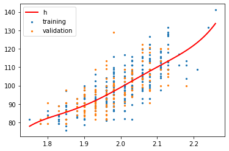

```python
get_h_plot()
```

## 記錄不同的高次項參數 `d` 對誤差與變異的影響

```python
X = players[['heightFeet', 'heightInches']].values
y = players['weightPounds'].values
```

```python
from sklearn.metrics import mean_squared_error

degrees = range(1, 11)
errors = []
variances = []
for degree in degrees:
    poly = PolynomialFeatures(degree)
    X_poly = poly.fit_transform(X)
    X_train, X_validation, y_train, y_validation = train_test_split(X_poly, y, test_size=0.33, random_state=42)
    lr = LinearRegression()
    lr.fit(X_train, y_train)
    y_pred = lr.predict(X_train)
    error = mean_squared_error(y_train, y_pred)
    y_pred = lr.predict(X_validation)
    variance = mean_squared_error(y_validation, y_pred)
    errors.append(error)
    variances.append(variance)
```

## 誤差與變異的平衡是由使用者來拿捏

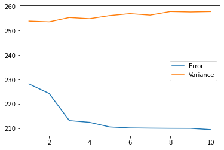

```python
fig, ax = plt.subplots()
ax.plot(degrees, errors, label="Error")
ax.plot(degrees, variances, label="Variance")
ax.legend()
plt.show()
```

## 「正規化」就是一種當 $h(X)$ 加入了許多特徵時避免過度配適的技巧

$$MSE_{train} = \frac{1}{m}\sum_i(wx^{train} - y^{(train)})_i^2 + \alpha \sum_{i} w_i^2 $$

## 具備正規化參數的 Normal equation

$$ \bigtriangledown_w MSE_{train} = 0 \\ \bigtriangledown_w \big((X^{(train)}w - y^{(train)})^T(X^{(train)}w - y^{(train)}) + \alpha w^Tw\big) = 0 \\ \frac{\partial}{\partial w} \big(w^TX^{(train)T}X^{(train)}w - 2w^TX^{(train)T}y^{(train)} + y^{(train)T}y^{(train)} + \alpha w^Tw\big) = 0 \\ 2X^{(train)T}X^{(train)}w - 2X^{(train)T}y^{(train)} + 2\alpha w = 0 \\ X^{(train)T}X^{(train)}w + \alpha w = X^{(train)T}y^{(train)} \\ (X^{(train)T}X^{(train)} + \alpha I)w = X^{(train)T}y^{(train)} \\ w = (X^{(train)T}X^{(train)} + \alpha I)^{-1} X^{(train)T}y^{(train)} $$

## Scikit-Learn 的 `Ridge` 類別

```python
from sklearn.linear_model import Ridge

X = players['heightMeters'].values.reshape(-1, 1)
y = players['weightKilograms'].values
poly = PolynomialFeatures(5)
X_poly = poly.fit_transform(X)
X_train, X_validation, y_train, y_validation = train_test_split(X_poly, y, test_size=0.33, random_state=42)
ridge = Ridge(alpha=0)
ridge.fit(X_train, y_train)
print(ridge.intercept_)
print(ridge.coef_)
```

```
-307708.8145756846
[      0.          779344.02032314 -787961.07992465  397602.26710642
 -100127.27276235   10068.19880362]
```

## 當 $\alpha = 0$ 與原本的 Normal Equation 解相同

```python
X = players['heightMeters'].values.reshape(-1, 1)
y = players['weightKilograms'].values
poly = PolynomialFeatures(3)
X_poly = poly.fit_transform(X)
X_train, X_validation, y_train, y_validation = train_test_split(X_poly, y, test_size=0.33, random_state=42)
lr = LinearRegression()
lr.fit(X_train, y_train)
print(lr.intercept_)
print(lr.coef_)
```

```
551.6292316151458
[   0.         -719.70059672  328.27885713  -40.80070897]
```

## $\alpha$ 愈大表示「正規化」程度愈高，意味著對 $w$ 的抑制愈大

```python
from sklearn.linear_model import Ridge

ridge = Ridge(alpha=1)
ridge.fit(X_train, y_train)
print(ridge.intercept_)
print(ridge.coef_)
```

```
28.72323688029087
[0.         0.10905805 1.55599065 8.00242732]
```

## $\alpha = 1000$ 時

```python
from sklearn.linear_model import Ridge

ridge = Ridge(alpha=1e3)
ridge.fit(X_train, y_train)
print(ridge.intercept_)
print(ridge.coef_)
```

```
79.01297182371304
[0.         0.17705386 0.70862407 2.13082583]
```

## 不同的 $\alpha$ 與其所對應的誤差、變異

```python
errors = []
variances = []
alphas = [0, 10, 1e2, 1e3, 1e4, 1e5, 1e6]
for alpha in alphas:
    ridge = Ridge(alpha=alpha)
    ridge.fit(X_train, y_train)
    y_pred = ridge.predict(X_train)
    error = mean_squared_error(y_train, y_pred)
    errors.append(error)
    y_pred = ridge.predict(X_validation)
    variance = mean_squared_error(y_validation, y_pred)
    variances.append(variance)
```

```python
error_table = pd.DataFrame()
error_table["alpha"] = alphas
error_table["errors"] = errors
error_table["variances"] = variances
error_table
```

|  | alpha | errors | variances |
| --- | --- | --- | --- |
| 0 | 0.0 | 46.893660 | 50.837241 |
| 1 | 10.0 | 47.067754 | 50.437013 |
| 2 | 100.0 | 50.240455 | 50.885993 |
| 3 | 1000.0 | 86.614795 | 80.485092 |
| 4 | 10000.0 | 117.531211 | 108.742177 |
| 5 | 100000.0 | 122.495707 | 113.365102 |
| 6 | 1000000.0 | 123.020797 | 113.855085 |

## 二元至多元（One vs. All）

## 到目前為止我們都只有面對二元分類問題

## 延展二元分類問題為多元分類問題常用的技巧稱為 One vs. All（或稱 One vs. Rest）

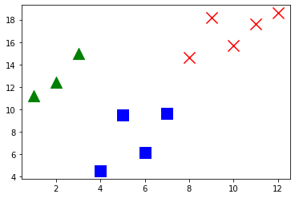

```python
get_demo_plot()
```

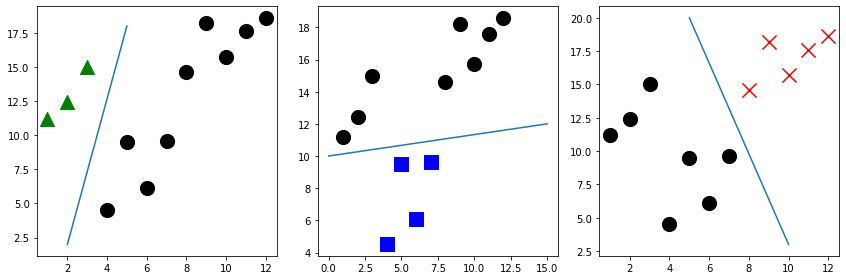

```python
get_demo_plot()
```

## 比較三種分類機率，取最大者

$$y \in {\{0, 1, 2\}}$$$$h^{0}(X) = P(y = 0 \mid X, w)$$$$h^{1}(X) = P(y = 1 \mid X, w)$$$$h^{2}(X) = P(y = 2 \mid X, w)$$$$\text{prediction:}\;\;max(h^{0}(X), h^{1}(X), h^{2}(X))$$

## 以 `players` 為例：如何延展二元分類為多元分類（`n = 7`）

```python
X = players['heightMeters'].values.reshape(-1, 1)
y = players["pos"].values
X_train, X_validation, y_train, y_validation = train_test_split(X, y, test_size=0.33, random_state=42)
unique_pos = np.unique(y)
pos_dict = {i : pos for pos, i in zip(unique_pos, range(unique_pos.size))}
print(pos_dict)
```

```
{0: 'C', 1: 'C-F', 2: 'F', 3: 'F-C', 4: 'F-G', 5: 'G', 6: 'G-F'}
```

```python
from sklearn.linear_model import LogisticRegression

def y_recoder(y, i):
    y_recoded = np.where(y == i, 0, 1)
    return y_recoded

y_probs = np.zeros((y_validation.size, unique_pos.size), dtype=float)
for i in range(unique_pos.size):
    y_train_recoded = y_recoder(y_train, unique_pos[i])
    lr = LogisticRegression()
    lr.fit(X_train, y_train_recoded)
    i_prob = lr.predict_proba(X_validation)[:, 1]
    y_probs[:, i] = i_prob
```

```python
print(y_probs[:10, :])
```

```
[[0.93303318 0.94027371 0.7052337  0.9078084  0.94559366 0.72345744
  0.8782464 ]
 [0.93602003 0.94210778 0.71310063 0.91157334 0.94571101 0.69681283
  0.87722481]
 [0.95033881 0.95128351 0.75404183 0.92989558 0.94635217 0.52992888
  0.87147357]
 [0.93303318 0.94027371 0.7052337  0.9078084  0.94559366 0.72345744
  0.8782464 ]
 [0.93602003 0.94210778 0.71310063 0.91157334 0.94571101 0.69681283
  0.87722481]
 [0.92499166 0.93544799 0.68502992 0.89775992 0.94529924 0.7833766
  0.88076838]
 [0.95579278 0.95498239 0.77129675 0.93700728 0.94664125 0.44919657
  0.86878428]
 [0.94295214 0.94646413 0.7322077  0.92038459 0.94600334 0.62442904
  0.87463855]
 [0.94295214 0.94646413 0.7322077  0.92038459 0.94600334 0.62442904
  0.87463855]
 [0.92830961 0.93742037 0.69320149 0.90189087 0.94541719 0.7605947
  0.87976505]]
```

```python
y_pred = np.zeros(y_validation.size, dtype=int)
for i in range(y_probs.shape[0]):
    max_idx = y_probs[i, :].argmax()
    y_pred[i] = max_idx
y_pred_pos = [pos_dict[i] for i in y_pred]
print(y_pred[:10])
print(y_pred_pos[:10])
```

```
[4 4 1 4 4 4 0 1 1 4]
['F-G', 'F-G', 'C-F', 'F-G', 'F-G', 'F-G', 'C', 'C-F', 'C-F', 'F-G']
```

## 不同的分類模型評估指標

## 常見用來評估分類模型的指標有

- 準確率
- Precision
- Recall
- $F_1 \text{ score}$
- AUC（Area under the ROC Curve）

## 分類模型的指標起源於混淆矩陣（Confusion Matrix）

> 混淆矩陣總結分類模型在預測的準確程度，混淆矩陣一軸是預測標籤，另一個軸是實際標籤

[figure not shown]

Source: https://en.wikipedia.org/wiki/Confusion_matrix

## 混淆矩陣（Confusion Matrix）由四個象限組成

- False positive，偽陽性，當 $\hat{y_i} = 1$ 但 $y_i = 0$
- True positive，真陽性，當 $\hat{y_i} = 1$ 與 $y_i = 1$
- False negative，偽陰性，當 $\hat{y_i} = 0$ 但 $y_i = 1$
- True negative，真陰性，當 $\hat{y_i} = 0$ 與 $y_i = 0$

## 如何創建混淆矩陣

```python
import numpy as np

y_true = np.round(np.random.rand(100)).astype(int)
y_pred = np.round(np.random.rand(100)).astype(int)
print(y_true)
print(y_pred)
```

```
[0 1 0 0 0 1 0 0 0 1 1 1 0 0 1 0 0 1 0 0 0 0 0 0 0 1 1 1 1 1 1 1 0 0 1 1 0
 1 0 0 0 0 0 0 0 1 0 1 1 0 1 1 0 0 0 0 0 0 0 0 1 0 1 0 1 1 1 1 1 0 1 1 0 0
 0 0 0 1 1 1 1 0 0 1 1 1 0 1 0 1 1 1 1 0 0 0 1 0 0 1]
[1 1 0 0 1 0 0 0 0 0 1 0 0 0 1 1 1 0 0 0 0 0 1 1 0 1 1 0 0 0 1 1 0 1 1 1 0
 0 0 1 0 0 1 0 1 0 0 0 0 1 0 0 0 0 0 1 0 0 0 0 0 0 1 1 1 0 1 0 0 0 0 1 0 0
 1 1 1 0 0 0 1 1 0 1 1 1 1 0 0 0 1 0 0 1 0 0 0 0 0 1]
```

```python
import numpy as np

confusion_matrix = np.zeros((2, 2), dtype=int)
for y_t, y_p in zip(y_true, y_pred):
    if y_t == 0 and y_p == 0:
        confusion_matrix[0, 0] += 1
    elif y_t == 1 and y_p == 1:
        confusion_matrix[1, 1] += 1
    elif y_t == 1 and y_p == 0:
        confusion_matrix[1, 0] += 1
    elif y_t == 0 and y_p == 1:
        confusion_matrix[0, 1] += 1
print(confusion_matrix)
```

```
[[36 19]
 [26 19]]
```

## 使用 `sklearn.metrics.confusion_matrix()` 創建混淆矩陣

```python
from sklearn.metrics import confusion_matrix

cm = confusion_matrix(y_true, y_pred)
print(cm)
```

```
[[36 19]
 [26 19]]
```

## 準確率（Accuracy）

> 準確率的計算：分子是正確分類數量，分母為總數

$$ accuracy = \frac{\text{TP + TN}}{\text{TP + TN + FP + FN}} $$

## Precision

> Precision 的計算：分子是正確分類數量，分母為預測陽性的數量

$$precision = \frac{\text{TP}}{\text{TP + FP}}$$

## Recall

> Recall 的計算：分子是正確分類數量，分母為真實陽性的數量

$$ recall = \frac{\text{TP}}{\text{TP + FN}} $$

## 多數的時候我們使用 Accuracy 評估分類模型的表現，但是 Accuracy 在陽性樣本比例極低的時候會失準，這時 Precision 與 Recall 就派上用場

## 以罕見疾病偵測為例子，10,000 的樣本中可能不到一個陽性，那我的分類器只要全部預測陰性，就可以達到 99% 以上的準確率

## Precision 與 Recall 說得白話一點

- Precision 看重實質是「陰性」卻被預測為「陽性」的樣本數（FP），意即正常卻被判斷為有罕見疾病
- Recall 看重實質是「陽性」卻被預測為「陰性」的樣本數（FN），意即有罕見疾病卻被判斷為正常

```python
import numpy as np
from sklearn.metrics import confusion_matrix

y_true = np.zeros(10000, dtype=int)
y_true[-1] = 1
y_pred = np.zeros(10000, dtype=int)
cm = confusion_matrix(y_true, y_pred)
print(cm)
```

```
[[9999    0]
 [   1    0]]
```

```python
acc = (cm[0, 0] + cm[1, 1]) / cm.sum()
precision = cm[1, 1] / (cm[1, 1] + cm[1, 0])
#recall = cm[1, 1] / (cm[1, 1] + cm[0, 1]) # zero-division
print("Accuracy: {:.2f}%".format(acc*100))
print("Precision: {:.2f}%".format(precision*100))
```

```
Accuracy: 99.99%
Precision: 0.00%
```

## $F_1$ score

> 考慮 Precision 與 Recall 的評估指標，兩者同等重要

$$ F_1 = 2 \times \frac{precision \times recall}{precision + recall} $$

## 泛化的 $F$ score

> 用 $\beta$ 來表示 Precision 與 Recall 的相等重要程度，$\beta = 1$ 表示同等重要（即 $F_1$）；$\beta = 0$ 即 Precision；$\beta = \infty$ 即 Recall

$$ F = (1+\beta^2) \times \frac{precision \times recall}{(\beta^2 \cdot precision) + recall} $$

## AUC（Area under the ROC Curve）

回憶從連續型的輸出 $Xw$ 到離散型的輸出 $\hat{y}$

$$ \hat{y} = g(h(X)) = H(\sigma(Xw)) \\ $$

## 階躍函數必須給定一個 Threshold（門檻值）

$$ \hat{y} = H(\sigma(z), threshold) = \begin{cases} 1 & \quad \text{if } \sigma(z)\geq threshold\\ 0 & \quad \text{otherwise}\\ \end{cases} $$

$$ FPR = \frac{FP}{FP + TN} \\ TPR = \frac{TP}{TP + FN} $$

## ROC Curve 底下的面積稱為 AUC，最理想的情況是 AUC 為 1；而 AUC 為 0.5，則是代表隨機挑選、沒有預測能力的分類模型，大部分情形都是落在這兩種之間

[figure not shown]

Source: 由 UPO649 1112 prodgom - 自己的作品, CC BY-SA 3.0, https://commons.wikimedia.org/w/index.php?curid=17086504